# Project 2: Data Mining, Classification, Prediction

SDS322E

# Mining, Classification, Prediction

## Tran Nguyen, tnn649

### Introduction

```r
library(tidyverse)
Fatalities <- read_csv("Fatalities.csv")

# Pulling the columns I want since there are a lot of
# variables
Fatalities1987 <- Fatalities %>% filter(year == "1987") %>% select(2,
    6, 8:9, 16, 21, 27) %>% group_by(state)
```

*My dataset is called “Fatalities1987” and it is a subset of a larger set called “Fatalities”. This dataset is from https://vincentarelbundock.github.io/ and is US traffic fatalities panel data for US states excluding Alaska and Hawaii which was collected anually 1982-1988.*

*In my subset, I am looking at 6 variables: The ‘state’ variable which identifies each state per row and the ‘income’ column is income in USD per capita. ‘beertax’ which is a numerical variable which indicates the tax on a case of beer. ‘baptist’ is a numeric variable which gives the percent of respondents that identify as Southern Baptist. ‘jail’ is a binary character variable that indicates if the state carries a mandatory jail sentence for DWIs. ‘fatal1517’ is a numeric variable that counts the number of vehicle fatalities in the 15-17 age group and ‘afatal’ counts the number of vehicle fatalities were alcohol-related.*

*Each variable has 48 observations and my categorical/binary variable has 34 ‘no’ responses and 14 ‘yes’ responses.*

### Cluster Analysis

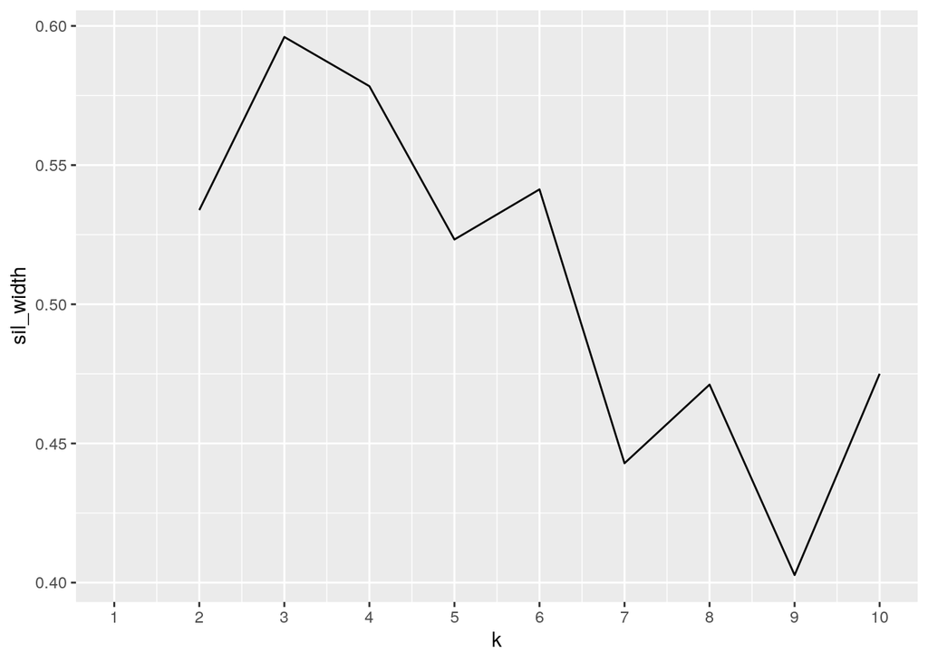

```r
library(cluster)

# only likes numerics so I've altered my frame to appease it
temp <- Fatalities1987 %>% select(2:4, 6:7)
Fatalities1987 <- Fatalities1987 %>% na.omit()
temp <- temp %>% remove_rownames %>% column_to_rownames(var = "state")

sil_width <- vector()  #empty vector to hold mean sil width
for (i in 2:10) {
    kms <- kmeans(temp, centers = i)  #compute k-means solution for each k
    sil <- silhouette(kms$cluster, dist(temp))  #get sil widths
    sil_width[i] <- mean(sil[, 3])  #take averages (higher is better)
}

# The highest sil width found at k=3
ggplot() + geom_line(aes(x = 1:10, y = sil_width)) + scale_x_continuous(name = "k",
    breaks = 1:10)
```

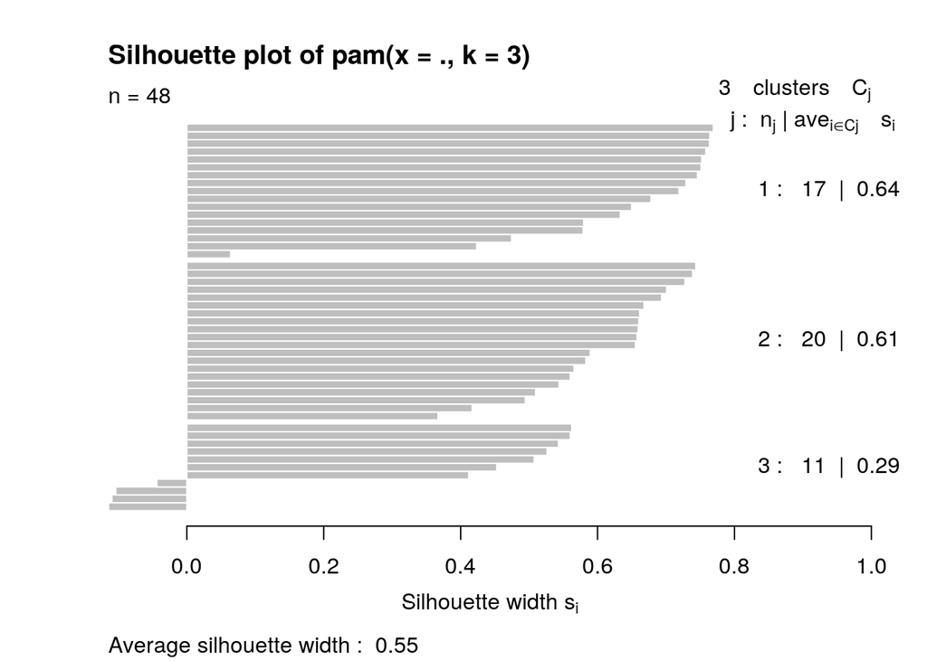

```r
pam1 <- temp %>% pam(k = 3)  #use the pam function
plot(pam1, which = 2)
```

```r
# PAM function
temp_pam <- temp %>% pam(k = 3)
temp_pam
```

```
## Medoids:
##    ID income  beertax baptist fatal1517  afatal
## ky 15  12008 0.181000 23.4058        80 255.851
## mo 23  14648 0.290461 14.8551        94 324.708
## ny 30  18005 0.123760  0.1000       157 479.830
## Clustering vector:
## al az ar ca co ct de fl ga id il in ia ks ky la me md ma mi mn ms mo mt ne nv
##  1  2  1  3  2  3  3  2  2  1  3  2  2  2  1  1  2  3  3  2  2  1  2  1  2  3
## nh nj nm ny nc nd oh ok or pa ri sc sd tn tx ut vt va wa wv wi wy
##  3  3  1  3  1  1  2  1  2  2  2  1  1  1  2  1  2  3  2  1  2  1
## Objective function:
##    build     swap
## 819.9162 797.6727
##
## Available components:
##  [1] "medoids"    "id.med"     "clustering" "objective"  "isolation"
##  [6] "clusinfo"   "silinfo"    "diss"       "call"       "data"
```

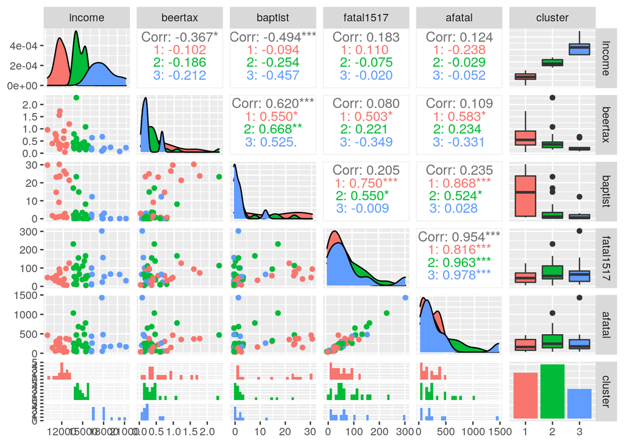

```r
# Pairwise combos
library(GGally)
tempclust <- temp %>% mutate(cluster = as.factor(temp_pam$cluster))

tempclust %>% ggpairs(cols = 1:7, aes(color = cluster))
```

*In my silhouette width ggplot, I found that k= 3 was a good number of clusters because it maximizes silhouette width more than is does at any other value up to k=10 thus the clusters would be more cohesive and separated and that New York, Kentucky, and Missouri are the representative medoids. My average silhouette width was 0.55 which indicates the structure to be reasonable.*

*It seems that the clusters take form in 3 tiers in which New York has the highest income, 15-17 age range fatalities, and alcohol-related fatalities while Kentucky is the lowest in each of the aforementioned with Missouri in the middle. This tier level is reversed when we look at the ‘baptist’ variable and then the order is completely different on the ‘beertax’ variable with Missouri having the highest followed by Kentucky and New York.*

*In the cluster pairs there is the strongest positive correlation observed between the ‘afatal’ and ‘fatal1517’ and the strongest negative between ‘baptist’ and ‘income’. There were also significant results observed between ‘beertax’ and ‘income’ which had a negative correlation and ‘baptist’ and ‘beertax’ which had a strong positive correlation.*

### Dimensionality Reduction with PCA

```r
temp_nums <- temp %>% select_if(is.numeric) %>% scale
rownames(temp_nums) <- Fatalities1987$state
temp_pca <- princomp(temp_nums)
names(temp_pca)
```

```
## [1] "sdev"     "loadings" "center"   "scale"    "n.obs"    "scores"   "call"
```

```r
summary(temp_pca, loadings = T)
```

```
## Importance of components:
##                           Comp.1    Comp.2    Comp.3     Comp.4      Comp.5
## Standard deviation     1.4597080 1.3520574 0.7596250 0.56325524 0.206737174
## Proportion of Variance 0.4352165 0.3733908 0.1178615 0.06480132 0.008729925
## Cumulative Proportion  0.4352165 0.8086073 0.9264688 0.99127007 1.000000000
##
## Loadings:
##           Comp.1 Comp.2 Comp.3 Comp.4 Comp.5
## income     0.197  0.547  0.733  0.350
## beertax   -0.406 -0.409  0.651 -0.494
## baptist   -0.493 -0.382         0.780
## fatal1517 -0.517  0.455 -0.113        -0.711
## afatal    -0.535  0.425 -0.156 -0.130  0.702
```

```r
eigval <- temp_pca$sdev^2
eigval
```

```
##     Comp.1     Comp.2     Comp.3     Comp.4     Comp.5
## 2.13074735 1.82805912 0.57703014 0.31725646 0.04274026
```

```r
eigval/sum(eigval)  #proportion of variance explained by each PC
```

```
##      Comp.1      Comp.2      Comp.3      Comp.4      Comp.5
## 0.435216480 0.373390800 0.117861475 0.064801320 0.008729925
```

```r
round(cumsum(eigval)/sum(eigval), 3)  #cumulative proportion of variance
```

```
## Comp.1 Comp.2 Comp.3 Comp.4 Comp.5
##  0.435  0.809  0.926  0.991  1.000
```

```r
temp_pcadf <- data.frame(cor(temp_pca$scores))
temp_pca$scores
```

```
##        Comp.1      Comp.2      Comp.3       Comp.4      Comp.5
## al -2.7293454 -2.11890229  0.76440344  0.239945035 -0.11822789
## az  0.5087396 -0.01147839 -0.24537339 -0.129372442  0.12041727
## ar -0.8922405 -1.51470729 -0.69933402  0.843970764 -0.06210508
## ca -3.3740461  4.87572943 -0.72604199 -0.410874712  0.25561744
## co  1.1148185  0.28800210 -0.03142000  0.215188679 -0.01761329
## ct  1.6783660  1.53133970  1.69455062  0.788888110  0.28041575
## de  1.7694225  0.15649051  0.26845943  0.335464422  0.13584477
## fl -2.3124275  1.17834497  0.68561575 -0.792520260  0.13869277
## ga -3.2014433 -1.67117928  2.37938855 -0.839224429 -0.05730814
## id  1.0291653 -0.88906119 -0.85217396 -0.527946951 -0.01423021
## il  0.1085833  1.38512241 -0.09993763  0.140644165  0.07211379
## in  0.1949974  0.47322397 -0.59055330 -0.266141478 -0.44541710
## ia  0.7786855 -0.09525319 -0.10173278 -0.394126972  0.06912566
## ks  0.7742789 -0.03133752  0.14817477 -0.016840751  0.14362382
## ky -0.7977995 -0.87095497 -1.14330344  1.280995197 -0.22027330
## la -0.7890421 -1.22562800 -0.53007092 -0.071697630  0.13617485
## me  0.9672555 -0.88926618  0.45375319 -0.772010547  0.08830915
## md  1.1074767  0.93751672  0.72888536  0.587820249 -0.02326769
## ma  1.1672834  1.33621500  1.00259247  0.401520790 -0.16108500
## mi -0.5770249  1.32924822 -0.07513456 -0.551287632 -0.27642870
##  [ reached getOption("max.print") -- omitted 28 rows ]
```

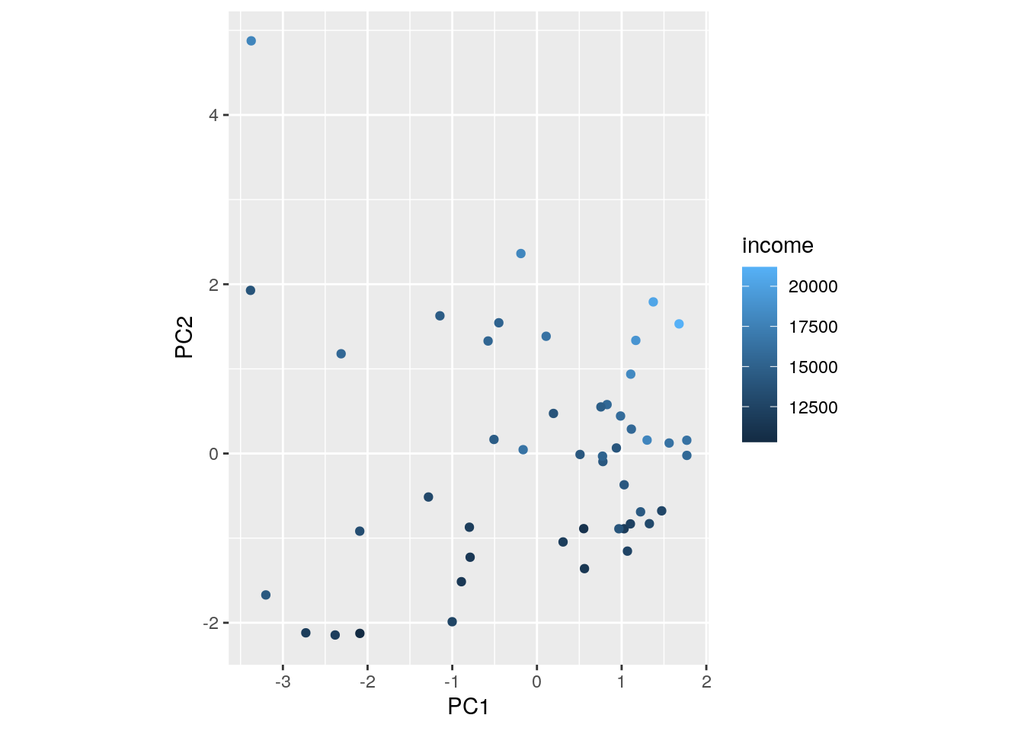

```r
temp %>% mutate(PC1 = temp_pca$scores[, 1], PC2 = temp_pca$scores[,
    2]) %>% ggplot(aes(PC1, PC2, color = income)) + geom_point() +
    coord_fixed()
```

### Linear Classifier

```r
TFatalities1987 <- Fatalities1987 %>% remove_rownames %>% column_to_rownames(var = "state")

logistic_fit <- glm(jail == "yes" ~ baptist + beertax + income +
    fatal1517 + afatal, data = TFatalities1987, family = "binomial")
score <- predict(logistic_fit, type = "response")
class_diag(score, TFatalities1987$jail, positive = "yes")
```

```
##            acc   sens   spec   ppv     f1     ba   auc
## Metrics 0.6667 0.2143 0.8529 0.375 0.2727 0.5336 0.729
```

```r
score %>% round(3)  #predicted probability for each obs
```

```
##    al    az    ar    ca    co    ct    de    fl    ga    id    il    in    ia
## 0.155 0.363 0.283 0.011 0.299 0.220 0.425 0.079 0.111 0.538 0.155 0.130 0.391
##    ks    ky    la    me    md    ma    mi    mn    ms    mo    mt    ne    nv
## 0.376 0.174 0.395 0.523 0.183 0.125 0.081 0.213 0.554 0.127 0.555 0.346 0.410
##    nh    nj    nm    ny    nc    nd    oh    ok    or    pa    ri    sc    sd
## 0.295 0.119 0.474 0.032 0.064 0.581 0.103 0.292 0.293 0.258 0.489 0.291 0.577
##    tn    tx    ut    vt    va    wa    wv    wi    wy
## 0.139 0.029 0.479 0.505 0.183 0.298 0.453 0.268 0.556
```

```r
table(truth = TFatalities1987$jail, predictions = score > 0.5) %>%
    addmargins()
```

```
##      predictions
## truth FALSE TRUE Sum
##   no     29    5  34
##   yes    11    3  14
##   Sum    40    8  48
```

*For my dataset, I used a logistic to predict my ‘jail’ variable which is a binary classifier that identifies a state carrying a mandatory jail sentence for DWIs with either a ‘yes’ or ‘no’. The model’s AUC was 0.729 which is “fair” performance.*

*In my confusion matrix, I had 29 true-negatives, 5 false-positives, 11 false-negatives, and 3 true-positives.*

```r
set.seed(322)
k = 10

data <- sample_frac(TFatalities1987)
folds <- rep(1:k, length.out = nrow(data))

diags <- NULL

i = 1
for (i in 1:k) {
    train <- data[folds != i, ]
    test <- data[folds == i, ]
    truth <- test$jail

    fit <- glm(jail == "yes" ~ ., data = train, family = "binomial")

    probs <- predict(fit, newdata = test, type = "response")

    diags <- rbind(diags, class_diag(probs, truth, positive = "yes"))
}

summarize_all(diags, mean)
```

```
##   acc sens    spec ppv  f1  ba     auc
## 1 0.6  NaN 0.80334 NaN NaN NaN 0.42501
```

### Non-Parametric Classifier

```r
library(caret)
fit <- knn3(jail ~ ., data = TFatalities1987)
probs <- predict(fit, newdata = TFatalities1987)[, 2]
class_diag(probs, TFatalities1987$jail, positive = "yes")
```

```
##            acc   sens   spec    ppv    f1     ba    auc
## Metrics 0.7292 0.2857 0.9118 0.5714 0.381 0.5987 0.6618
```

```r
table(truth = TFatalities1987$jail, predictions = probs > 0.5) %>%
    addmargins
```

```
##      predictions
## truth FALSE TRUE Sum
##   no     31    3  34
##   yes    10    4  14
##   Sum    41    7  48
```

*I used the knn method to predict my ‘jail’ variable which is a binary classifier that identifies a state carrying a mandatory jail sentence for DWIs with either a ‘yes’ or ‘no’. The knn model’s AUC on my dataset is 0.6618 which means it is performing pretty poorly.*

*In my confusion matrix, there are 31 true-negatives, 3 false-positives, 10 false-negatives, and 4 true positives.*

```r
set.seed(322)
k = 10

data <- sample_frac(TFatalities1987)
folds <- rep(1:k, length.out = nrow(data))

diags <- NULL

i = 1
for (i in 1:k) {
    train <- data[folds != i, ]
    test <- data[folds == i, ]
    truth <- test$jail

    # train model
    fit <- knn3(jail == "yes" ~ ., data = train)

    # test model
    probs <- predict(fit, newdata = test)[, 2]

    diags <- rbind(diags, class_diag(probs, truth, positive = "yes"))
}
summarize_all(diags, mean)
```

```
##   acc sens spec ppv  f1  ba     auc
## 1 0.6  NaN 0.84 NaN NaN NaN 0.31667
```

*In the k-fold CV, my model performs poorly with an AUC of 0.31667. Since it dropped from my original knn model with an AUC of 0.6618, there seems to be indication of overfitting. Compared to how my linear model performed, my non-parametric model performed more poorly.*

### Regression/Numeric Prediction

```r
fit <- lm(beertax ~ afatal + fatal1517 + baptist, data = TFatalities1987)
yhat <- predict(fit)
mean((TFatalities1987$beertax - yhat)^2)
```

```
## [1] 0.1227412
```

*The MSE for my dataset when I predict ‘beertax’ using ‘afatal’, ‘baptist’, and ‘fatal1517’ is 0.123.*

```r
# Perform k-fold CV on this same model (fine to use caret).
# Calculate the average MSE across your k testing folds.
set.seed(1234)
k = 10
data <- TFatalities1987[sample(nrow(TFatalities1987)), ]  #randomly order rows
folds <- cut(seq(1:nrow(TFatalities1987)), breaks = k, labels = F)  #create folds
diags <- NULL
for (i in 1:k) {
    train <- data[folds != i, ]
    test <- data[folds == i, ]
    ## training set
    fit <- lm(beertax ~ afatal + fatal1517 + baptist, data = train)
    ## test set (fold i)
    yhat <- predict(fit, newdata = test)
    ## MSE
    diags <- mean((test$beertax - yhat)^2)
}
mean(diags)
```

```
## [1] 0.1372941
```

### Python

```r
library(reticulate)
py_install("pandas")
py_install("seaborn")
use_python("/usr/bin/python3", required = F)
```

```python
import pandas as pd
import seaborn as sns
Fatalities = pd.read_csv("Fatalities.csv")
Fatalities.head()
```

```
##    Unnamed: 0 state  year  spirits  ...  milestot  unempus   emppopus       gsp
## 0           1    al  1982     1.37  ...   28516.0      9.7  57.799999 -0.022125
## 1           2    al  1983     1.36  ...   31032.0      9.6  57.900002  0.046558
## 2           3    al  1984     1.32  ...   32961.0      7.5  59.500004  0.062798
## 3           4    al  1985     1.28  ...   35091.0      7.2  60.100002  0.027490
## 4           5    al  1986     1.23  ...   36259.0      7.0  60.700001  0.032143
##
## [5 rows x 35 columns]
```

*In this chunk, I loaded in my dataset and used .head() to get a peek at what my data looks like when it was loaded in.*